# Bulk RNA-seq in nivolumab-treated melanoma: a reanalysis of Riaz et al. (2017)

Ethan (RNA lead) · Group: Krithika (TCR), Ethan (RNA), Kwaku (WES)

November 07, 2026

**Analysis by:** Ethan (bulk RNA sequencing). **Source:** Riaz et al., *Cell* 2017, [DOI 10.1016/j.cell.2017.09.028](https://doi.org/10.1016/j.cell.2017.09.028); processed data from riazn/bms038_analysis, in the repository’s `data/` folder.

# Background

**Nivolumab** blocks PD-1, a brake on T cells. It works in only some melanoma patients. Kwaku’s exome analysis asks whether tumors lose their mutations when it works. This analysis asks the matching question for gene expression.

**Bulk RNA-seq** counts the RNA reads from each gene across all cells in a biopsy, so it reads out both the immune response and the tumor. We compare biopsies from before treatment and about 4 weeks in, across PR/CR (partial or complete response), SD (stable disease) and PD (progressive disease).

**Question:** what changes in gene expression on nivolumab, and is the change specific to responders?

# Workflow

All code is in `rna/`. Each chunk below runs one script. Code is folded; use the **Code** buttons to read it. The first run takes about 20 minutes because of DESeq2; later runs reuse `rna/results/cache/`.

## Step 1: counts, filtering and normalization

Read the raw counts, take each patient’s ID from the sample name (the table’s `PatientID` mislabels Pt7_Pre as Pt72), keep genes with at least 10 reads in at least 5 samples, and apply DESeq2’s variance-stabilizing transform (VST).

```r
# Step 1: read counts and sample table, filter genes, normalize (VST), QC figures
source("rna/common.R")
suppressPackageStartupMessages(library(org.Hs.eg.db))

counts <- read.delim(file.path(data_dir, "CountData.BMS038.txt"), check.names = FALSE)  # rows = Entrez IDs
geno   <- read.csv(file.path(data_dir, "genomic_data_per_case.csv"))
shared <- geno$Patient[rowSums(geno[-1]) == 6]  # WES + TCR + RNA at both biopsies

samples <- read.csv(file.path(data_dir, "SampleTableCorrected.9.19.16.csv")) |>
  transmute(sample   = Sample,
            patient  = sub("_.*", "", Sample),  # PatientID column mislabels Pt7_Pre as Pt72
            time     = factor(PreOn, c("Pre", "On")),
            response = factor(Response, c("PD", "SD", "PRCR")),
            benefit  = factor(Response.1, c("NB", "LB")),
            cohort   = Cohort) |>
  filter(!is.na(response), sample %in% colnames(counts)) |>
  mutate(shared = patient %in% shared)

dds <- DESeqDataSetFromMatrix(as.matrix(counts[, samples$sample]),
                              column_to_rownames(samples, "sample"), ~ 1)
dds <- dds[rowSums(counts(dds) >= 10) >= 5, ]
rowData(dds)$symbol <- mapIds(org.Hs.eg.db, rownames(dds), "SYMBOL", "ENTREZID")
dds <- estimateSizeFactors(dds)
vsd <- vst(dds, blind = TRUE)
saveRDS(dds, file.path(cache, "dds.rds"))
saveRDS(vsd, file.path(cache, "vsd.rds"))
write_csv(samples, file.path(out, "samples.csv"))

cat(ncol(dds), "samples,", nrow(dds), "genes after filtering\n")
print(with(samples, table(response, time)))

# QC: reads per sample
qc <- as.data.frame(colData(dds)) |> rownames_to_column("sample") |>
  mutate(reads_M = colSums(counts(dds)) / 1e6, Response = resp(response))
p <- ggplot(qc, aes(reorder(sample, reads_M), reads_M, fill = Response)) + geom_col() +
  facet_grid(~ time, scales = "free_x", space = "free_x") +
  scale_fill_manual(values = resp_cols) +
  labs(x = NULL, y = "Assigned reads (millions)", title = "Library size per sample") +
  theme(axis.text.x = element_blank(), axis.ticks.x = element_blank())
save_supp(p, "S01_library_size", 9, 4)

# QC: PCA on the 500 most variable genes
pca <- plotPCA(vsd, intgroup = c("time", "response"), ntop = 500, returnData = TRUE)
pv  <- round(100 * attr(pca, "percentVar"))
p <- ggplot(pca, aes(PC1, PC2, colour = resp(response), shape = time)) +
  geom_point(size = 2.5, alpha = 0.85) + scale_colour_manual(values = resp_cols) +
  labs(x = paste0("PC1 (", pv[1], "%)"), y = paste0("PC2 (", pv[2], "%)"), colour = "Response", shape = NULL,
       title = "PCA of normalized expression (top 500 genes)")
save_supp(p, "S02_pca", 7, 5)
```

## Step 2: differential expression

Negative-binomial models in DESeq2: baseline PR/CR vs PD; On vs Pre with each patient as their own control; and On vs Pre within each response group, with a formal test of whether the change differs between groups.

```r
# Step 2: DESeq2 differential expression
#  A) Pre-treatment PR/CR vs PD: is there a baseline signature of response?
#  B) On vs Pre, paired by patient: what does nivolumab change overall?
#  C) On vs Pre within each response group, plus PR/CR change minus PD change
#  D) Benefit (PR/CR + SD) change minus no-benefit change: the paper's grouping
source("rna/common.R")
dds <- readRDS(file.path(cache, "dds.rds"))
vsd <- readRDS(file.path(cache, "vsd.rds"))
sym <- rowData(dds)$symbol
tidy_res <- function(r) as.data.frame(r) |> rownames_to_column("entrez") |>
  mutate(symbol = sym[match(entrez, rownames(dds))]) |> arrange(padj)

# A. Same four sample exclusions as the authors' Table S6A script
pre <- dds[, dds$time == "Pre" & !colnames(dds) %in% c("Pt48_Pre", "Pt67_Pre", "Pt52_Pre", "Pt27_Pre")]
design(pre) <- ~ response
pre <- cached("fit_A", DESeq(pre, quiet = TRUE))
shr <- lfcShrink(pre, coef = "response_PRCR_vs_PD", type = "apeglm", quiet = TRUE)
shr$stat <- results(pre, name = "response_PRCR_vs_PD")$stat
res_A <- tidy_res(shr)

# B. Every patient is their own control
paired <- names(which(table(dds$patient) == 2))
onpre  <- dds[, dds$patient %in% paired]
onpre$patient <- factor(onpre$patient)
design(onpre) <- ~ patient + time
fit_B <- cached("fit_B", DESeq(onpre, quiet = TRUE))
res_B <- tidy_res(results(fit_B, name = "time_On_vs_Pre"))

# C/D. Patients nested in group (DESeq2 vignette design), so On vs Pre is estimated per group
nested_fit <- function(group) {
  x <- onpre; x$grp <- x[[group]]
  x$ind <- as.data.frame(colData(x)) |> mutate(ind = factor(as.integer(droplevels(patient))), .by = grp) |> pull(ind)
  mm <- model.matrix(~ grp + grp:ind + grp:time, colData(x))
  DESeq(x, full = mm[, colSums(mm != 0) > 0], betaPrior = FALSE, quiet = TRUE)
}
fit_C <- cached("fit_C", nested_fit("response"))
res_C <- list(PRCR = results(fit_C, name = "grpPRCR.timeOn"),
              SD   = results(fit_C, name = "grpSD.timeOn"),
              PD   = results(fit_C, name = "grpPD.timeOn"),
              PRCR_vs_PD = results(fit_C, contrast = list("grpPRCR.timeOn", "grpPD.timeOn"))) |> map(tidy_res)
fit_D <- cached("fit_D", nested_fit("benefit"))
res_D <- tidy_res(results(fit_D, contrast = list("grpLB.timeOn", "grpNB.timeOn")))

all_res <- c(list(A_pre_PRCR_vs_PD = res_A, B_on_vs_pre_paired = res_B),
             set_names(res_C, paste0("C_on_vs_pre_", names(res_C))),
             list(D_on_vs_pre_benefit_vs_none = res_D))
iwalk(all_res, \(r, n) write_csv(r, file.path(out, paste0("de_", n, ".csv"))))

de_summary <- imap_dfr(all_res, \(r, n) tibble(contrast = n, genes_tested = sum(!is.na(r$padj)),
                                               fdr_0.1 = sum(r$padj < 0.1, na.rm = TRUE),
                                               fdr_0.2 = sum(r$padj < 0.2, na.rm = TRUE)))
write_csv(de_summary, file.path(out, "de_summary.csv"))
print(de_summary)
print(table(colData(onpre)$response) / 2)

# Supplementary figures
immune_genes <- c("CD8A", "GZMB", "GZMH", "PRF1", "IFNG", "CXCL9", "CXCL10", "CXCL13",
                  "PDCD1", "LAG3", "TIGIT", "CD274", "GBP5", "STAT1", "IDO1", "NKG7")
volcano <- function(res, title) {
  res <- filter(res, !is.na(padj))
  lab <- bind_rows(head(res, 15), filter(res, symbol %in% immune_genes, padj < 0.1)) |> distinct(entrez, .keep_all = TRUE)
  ggplot(res, aes(log2FoldChange, -log10(pvalue))) +
    geom_point(aes(colour = case_when(padj >= 0.1 ~ "ns", log2FoldChange > 0 ~ "Up", TRUE ~ "Down")), size = 0.7, alpha = 0.6) +
    geom_text_repel(data = lab, aes(label = symbol), size = 3, max.overlaps = 30, segment.size = 0.2) +
    scale_colour_manual(values = c(ns = GREY, Up = UP, Down = DOWN), name = "FDR < 0.1") +
    labs(title = title, subtitle = paste(sum(res$padj < 0.1), "genes at FDR < 0.1"), x = "log2 fold change", y = "-log10 p")
}
save_supp(volcano(res_A, "Pre-treatment: PR/CR vs PD"), "S03_volcano_pre_PRCR_vs_PD", 7.5, 5.5)
save_supp(volcano(res_B, "On vs Pre, paired, all patients"), "S04_volcano_on_vs_pre", 7.5, 5.5)

lfc <- inner_join(select(res_C$PRCR, entrez, symbol, PRCR = log2FoldChange),
                  select(res_C$PD, entrez, PD = log2FoldChange), by = "entrez") |>
  left_join(select(res_C$PRCR_vs_PD, entrez, padj_int = padj), by = "entrez") |>
  mutate(sig = !is.na(padj_int) & padj_int < 0.1)
p <- ggplot(lfc, aes(PD, PRCR)) +
  geom_hline(yintercept = 0, colour = "grey60") + geom_vline(xintercept = 0, colour = "grey60") +
  geom_abline(linetype = 2, colour = "grey50") +
  geom_point(aes(colour = sig), size = 0.6, alpha = 0.6) +
  geom_text_repel(data = filter(lfc, symbol %in% immune_genes), aes(label = symbol), size = 3, max.overlaps = 30) +
  scale_colour_manual(values = c(`FALSE` = GREY, `TRUE` = DOWN), labels = c("No", "Yes"), name = "Differs by group\n(FDR < 0.1)") +
  coord_cartesian(xlim = c(-4, 4), ylim = c(-4, 6)) +
  labs(title = "On-treatment change: responders vs progressors", x = "log2 On/Pre in PD", y = "log2 On/Pre in PR/CR")
save_supp(p, "S05_lfc_PRCR_vs_PD", 7.5, 5.5)

top <- head(filter(res_B, !is.na(symbol)), 40)
v   <- assay(vsd)[top$entrez, colnames(onpre)]; rownames(v) <- top$symbol
ann <- as.data.frame(colData(onpre))[, "time", drop = FALSE]; ann$Response <- resp(onpre$response)
ord <- order(ann$time, ann$Response)
pheatmap(t(scale(t(v[, ord]))), cluster_cols = FALSE, show_colnames = FALSE, annotation_col = ann[ord, ],
         breaks = seq(-2.5, 2.5, length.out = 101), color = colorRampPalette(c(DOWN, "white", UP))(100),
         annotation_colors = list(Response = resp_cols, time = c(Pre = "grey80", On = "grey30")),
         main = "Top 40 genes changed on nivolumab (row z-score)", fontsize_row = 7,
         filename = file.path(supp, "S06_heatmap_top_on_vs_pre.png"), width = 8, height = 7)
```

## Step 3: pathways

Genes ranked by the DESeq2 statistic, then tested with fgsea against the MSigDB Hallmark sets.

```r
# Step 3: pathway view. fgsea on MSigDB Hallmark sets, genes ranked by the DESeq2 Wald statistic.
source("rna/common.R")
set.seed(1)
h <- msigdbr(species = "Homo sapiens", collection = "H")
hallmark <- split(h$gene_symbol, h$gs_name)
contrasts <- c(`PR/CR vs PD` = "A_pre_PRCR_vs_PD", `All patients` = "B_on_vs_pre_paired",
               `PR/CR` = "C_on_vs_pre_PRCR", SD = "C_on_vs_pre_SD", PD = "C_on_vs_pre_PD")
gsea <- imap_dfr(contrasts, \(f, nm) {
  r <- read_csv(file.path(out, paste0("de_", f, ".csv")), show_col_types = FALSE) |>
    filter(!is.na(stat), !is.na(symbol)) |> slice_max(abs(stat), n = 1, by = symbol, with_ties = FALSE)
  as_tibble(fgsea(hallmark, setNames(r$stat, r$symbol), minSize = 15, maxSize = 500)) |> mutate(contrast = nm)
})
write_csv(select(gsea, -leadingEdge), file.path(out, "gsea_hallmark.csv"))

# Figure 04: the two programs the paper reports, immune up and proliferation down
programs <- c(HALLMARK_INTERFERON_GAMMA_RESPONSE = "Interferon-gamma response", HALLMARK_INTERFERON_ALPHA_RESPONSE = "Interferon-alpha response",
              HALLMARK_ALLOGRAFT_REJECTION = "Allograft rejection (T-cell killing)", HALLMARK_INFLAMMATORY_RESPONSE = "Inflammatory response",
              HALLMARK_E2F_TARGETS = "E2F targets", HALLMARK_G2M_CHECKPOINT = "G2M checkpoint",
              HALLMARK_MYC_TARGETS_V1 = "MYC targets", HALLMARK_MITOTIC_SPINDLE = "Mitotic spindle")
d <- gsea |> filter(pathway %in% names(programs), contrast != "All patients") |>
  mutate(label = factor(programs[pathway], rev(programs)),
         program = factor(if_else(pathway %in% names(programs)[1:4], "Immune", "Proliferation"), c("Immune", "Proliferation")),
         column = factor(contrast, c("PR/CR vs PD", "PR/CR", "SD", "PD")),
         panel = factor(if_else(contrast == "PR/CR vs PD", "Before treatment", "On vs Pre, by response"), c("Before treatment", "On vs Pre, by response")),
         sig_nes = if_else(padj < 0.05, NES, NA_real_))
p <- ggplot(d, aes(column, label, fill = sig_nes)) +
  geom_tile(colour = "white", linewidth = 1) + geom_text(aes(label = sprintf("%.1f", NES)), size = 4.6) +
  facet_grid(program ~ panel, scales = "free", space = "free") +
  scale_fill_gradient2(low = DOWN, mid = "white", high = UP, midpoint = 0, limits = c(-3.8, 3.8), na.value = "grey93", name = "NES") +
  labs(x = NULL, y = NULL, title = "Hallmark pathways before and during nivolumab",
       caption = "Number = normalized enrichment score. Orange = higher in PR/CR (left) or on treatment (right); grey = FDR >= 0.05.") +
  theme(panel.grid = element_blank(), strip.background = element_rect(fill = "grey92"))
save_plot(p, "04_pathways_by_response", 10, 6)
gsea |> filter(pathway %in% names(programs)) |> select(contrast, pathway, NES, padj) |> arrange(pathway, contrast) |> print(n = 50)

# Supplementary: top 20 pathways across all contrasts
keep <- gsea |> summarise(p = min(padj), .by = pathway) |> slice_min(p, n = 20, with_ties = FALSE) |> pull(pathway)
d2 <- gsea |> filter(pathway %in% keep) |>
  mutate(pathway = str_to_sentence(str_replace_all(str_remove(pathway, "HALLMARK_"), "_", " ")),
         contrast = factor(contrast, names(contrasts)))
lvl <- d2 |> filter(contrast == "PR/CR") |> arrange(NES) |> pull(pathway)
d2$pathway <- factor(d2$pathway, unique(c(lvl, d2$pathway)))
p <- ggplot(d2, aes(contrast, pathway, colour = NES, size = -log10(padj))) + geom_point() +
  geom_point(data = filter(d2, padj < 0.05), shape = 1, colour = "black", stroke = 0.6) +
  scale_colour_gradient2(low = DOWN, mid = "white", high = UP) + scale_size_continuous(range = c(0.5, 5)) +
  labs(x = NULL, y = NULL, title = "Hallmark enrichment, top 20 pathways", subtitle = "Outlined = FDR < 0.05") +
  theme(axis.text.x = element_text(angle = 30, hjust = 1), axis.text.y = element_text(size = 10))
save_supp(p, "S07_gsea_top20", 9, 7)
```

## Step 4: signature scores and patient table

Each score is the mean z-scored expression of marker genes. `rna_patient_features.csv` is the table for the group’s integration.

```r
# Step 4: patient-level measures -> figures 01-03 and the table the group joins on.
#  Score = mean z-scored VST expression of marker genes (MCP-counter-style cell-type markers;
#  Ayers 2017 IFN-gamma and T-cell-inflamed sets). Melanocytic score = tumour-content proxy.
source("rna/common.R")
vsd <- readRDS(file.path(cache, "vsd.rds"))
samples <- read_csv(file.path(out, "samples.csv"), show_col_types = FALSE) |> mutate(time = factor(time, c("Pre", "On")))
sym <- rowData(vsd)$symbol

sigs <- list(
  T_cells = c("CD3D", "CD3E", "CD3G", "CD28", "CD6", "TRAT1"),
  CD8_T = c("CD8A", "CD8B"),
  Cytotoxic = c("GZMA", "GZMB", "GZMH", "PRF1", "NKG7", "GNLY"),
  NK = c("KLRD1", "KLRF1", "NCR1", "SH2D1B"),
  B_cells = c("CD19", "MS4A1", "CD79A", "CR2", "FCRL2"),
  Myeloid = c("CD14", "CD163", "CD68", "CSF1R", "FCGR3A"),
  Treg = c("FOXP3", "IL2RA", "CTLA4"),
  IFNG_6 = c("IFNG", "STAT1", "IDO1", "CXCL9", "CXCL10", "HLA-DRA"),
  Tcell_inflamed_18 = c("CCL5", "CD27", "CD274", "CD276", "CD8A", "CMKLR1", "CXCL9", "CXCR6", "HLA-DQA1",
                        "HLA-DRB1", "HLA-E", "IDO1", "LAG3", "NKG7", "PDCD1LG2", "PSMB10", "STAT1", "TIGIT"),
  Checkpoints = c("PDCD1", "CD274", "LAG3", "HAVCR2", "TIGIT", "CTLA4"),
  Antigen_pres = c("HLA-A", "HLA-B", "HLA-C", "B2M", "TAP1", "TAP2", "PSMB8", "PSMB9"),
  Melanocytic = c("MITF", "PMEL", "TYR", "MLANA", "DCT"))

z <- t(scale(t(assay(vsd))))
scores <- sapply(sigs, \(g) colMeans(z[na.omit(match(g, sym)), , drop = FALSE]))
write_csv(as_tibble(scores, rownames = "sample"), file.path(out, "signature_scores_per_sample.csv"))

long <- as_tibble(scores, rownames = "sample") |> left_join(samples, by = "sample") |>
  pivot_longer(names(sigs), names_to = "signature", values_to = "score") |>
  mutate(signature = factor(signature, names(sigs)))

# Per-patient table: Pre, On, change
rna_patient <- long |> select(patient, response, benefit, cohort, shared, time, signature, score) |>
  pivot_wider(names_from = c(signature, time), values_from = score, names_sep = "_")
for (s in names(sigs)) rna_patient[[paste0(s, "_delta")]] <- rna_patient[[paste0(s, "_On")]] - rna_patient[[paste0(s, "_Pre")]]

# Share of genes changing at least 2-fold between a patient's two biopsies (1 VST unit is about 2-fold)
m <- assay(vsd)
paired <- intersect(rna_patient$patient[!is.na(rna_patient$CD8_T_delta)], samples$patient)
gene_change <- map_dfr(paired, \(p) {
  d <- m[, paste0(p, "_On")] - m[, paste0(p, "_Pre")]
  tibble(patient = p, genes_up = mean(d >= 1), genes_down = mean(d <= -1), genes_changed = genes_up + genes_down)
})
rna_patient <- left_join(rna_patient, gene_change, by = "patient")
write_csv(rna_patient, file.path(out, "rna_patient_features.csv"))
cat("Patients:", nrow(rna_patient), " Paired:", length(paired), " Paired and shared:", sum(rna_patient$shared & !is.na(rna_patient$CD8_T_delta)), "\n")

# Noise floor: same measure between repeat libraries of one biopsy label (the ".2" columns in the count table)
counts <- read.delim(file.path(data_dir, "CountData.BMS038.txt"), check.names = FALSE)[rownames(vsd), ]
reps <- intersect(grep("[.]2$", colnames(counts), value = TRUE), paste0(colnames(counts), ".2"))
rep_vst <- vst(as.matrix(counts[, setdiff(colnames(counts), "HUGO")]), blind = TRUE)
replicate_noise <- tibble(library = reps, genes_changed = map_dbl(reps, \(r) mean(abs(rep_vst[, r] - rep_vst[, sub("[.]2$", "", r)]) >= 1)))
write_csv(replicate_noise, file.path(out, "replicate_noise.csv"))
print(replicate_noise); cat("Median repeat-library share:", median(replicate_noise$genes_changed), "\n")

# Figure 01: baseline immune score (the RNA counterpart of baseline mutation burden)
d <- filter(rna_patient, !is.na(Tcell_inflamed_18_Pre)) |>
  mutate(Response = resp(response), Cohort = recode(cohort, `NIV3-NAIVE` = "No prior ipilimumab", `NIV3-PROG` = "Progressed on ipilimumab"))
p <- ggplot(d, aes(Response, Tcell_inflamed_18_Pre, colour = Response)) +
  geom_hline(yintercept = 0, linetype = 2, colour = "grey60") +
  geom_boxplot(outlier.shape = NA) + geom_point(position = position_jitter(width = .12, seed = 38), size = 2) +
  facet_wrap(~ Cohort) + scale_colour_manual(values = resp_cols) + theme_bw(base_size = 16) + theme(legend.position = "none") +
  labs(title = "Baseline immune activity by clinical response", y = "T-cell-inflamed score (z-score)", x = NULL,
       caption = "Each point is one patient's pre-treatment biopsy. Prior-ipilimumab cohorts shown separately.")
save_plot(p, "01_baseline_immune_by_response")

# Figure 02: gene changes per patient (the RNA counterpart of mutation changes per patient)
d <- filter(rna_patient, !is.na(genes_changed)) |> mutate(Response = resp(response)) |>
  pivot_longer(c(genes_up, genes_down), names_to = "Direction", values_to = "share") |>
  mutate(Direction = factor(Direction, c("genes_down", "genes_up"), c("Down on treatment", "Up on treatment")))
p <- ggplot(d, aes(reorder(patient, genes_changed), share, fill = Direction)) + geom_col() +
  facet_grid(~ Response, scales = "free_x", space = "free_x") +
  scale_fill_manual(values = c(DOWN, UP)) + scale_y_continuous(labels = scales::percent) +
  theme_bw(base_size = 14) + theme(axis.text.x = element_text(angle = 90, hjust = 1, vjust = .5, size = 10), legend.position = "bottom") +
  labs(title = "Gene expression changes during nivolumab treatment", y = "Share of genes changing at least 2-fold", x = "Patient", fill = NULL,
       caption = sprintf("%s genes measured; patients sorted by amount of change within each group.", format(nrow(m), big.mark = ",")))
save_plot(p, "02_gene_changes_per_patient", 12, 6)

# Figure 03: tumour and immune change per patient (the RNA counterpart of the neoantigen ranking)
d <- filter(rna_patient, !is.na(CD8_T_delta)) |> mutate(Response = resp(response), ord = Melanocytic_delta) |>
  select(patient, Response, ord, `Tumor score change (melanocytic genes)` = Melanocytic_delta, `CD8 T-cell score change` = CD8_T_delta) |>
  pivot_longer(c(-patient, -Response, -ord), names_to = "measure", values_to = "change") |>
  mutate(measure = factor(measure, c("Tumor score change (melanocytic genes)", "CD8 T-cell score change")))
p <- ggplot(d, aes(change, reorder(patient, ord), colour = Response, shape = Response)) +
  geom_vline(xintercept = 0, linetype = 2) + geom_point(size = 2.8) +
  facet_wrap(~ measure, scales = "free_x") + scale_colour_manual(values = resp_cols) +
  theme_bw(base_size = 14) + theme(axis.text.y = element_text(size = 10), legend.position = "bottom") +
  labs(title = "Tumor and immune change in each patient", x = "On minus Pre (z-score units)", y = "Patient", colour = NULL, shape = NULL,
       caption = "Patients sorted by tumor score change. Left of the dashed line = score fell on treatment.")
save_plot(p, "03_tumor_immune_change_per_patient", 10, 9)

# Supplementary: trajectories, effect sizes, per-patient heatmap, tumour-content check
key <- c("CD8_T", "Cytotoxic", "IFNG_6", "Tcell_inflamed_18", "Checkpoints", "Melanocytic")
tr <- long |> filter(signature %in% key) |> group_by(patient) |> filter(n_distinct(time) == 2) |> ungroup() |> mutate(Response = resp(response))
p <- ggplot(tr, aes(time, score, group = patient, colour = Response)) + geom_line(alpha = 0.45) + geom_point(size = 0.9) +
  stat_summary(aes(group = Response), fun = median, geom = "line", linewidth = 1.4) +
  facet_grid(Response ~ signature) + scale_colour_manual(values = resp_cols, guide = "none") +
  labs(x = NULL, y = "Signature score (mean z)", title = "Per-patient change in signatures", subtitle = "Thin = patient, thick = group median")
save_supp(p, "S08_signature_trajectories", 12, 6.5)

hl <- function(d) {  # Hodges-Lehmann shift, PR/CR minus PD
  w <- wilcox.test(value ~ droplevels(factor(response, c("PD", "PRCR"))), data = d, conf.int = TRUE, exact = FALSE)
  tibble(n_PD = sum(d$response == "PD"), n_PRCR = sum(d$response == "PRCR"), est = -w$estimate, lo = -w$conf.int[2], hi = -w$conf.int[1], p = w$p.value)
}
eff <- map_dfr(c(all = FALSE, shared = TRUE), \(only) {
  rna_patient |> filter(response != "SD", !only | shared) |>
    pivot_longer(matches("_(Pre|On|delta)$"), names_to = "feature", values_to = "value") |> filter(!is.na(value)) |>
    separate(feature, c("signature", "when"), sep = "_(?=[^_]+$)") |>
    group_by(signature, when) |> group_modify(~ hl(.x)) |> ungroup()
}, .id = "set") |> mutate(padj = p.adjust(p, "BH"), .by = set) |>
  mutate(signature = factor(signature, rev(names(sigs))), when = factor(when, c("Pre", "On", "delta")))
write_csv(eff, file.path(out, "signature_effect_sizes_PRCR_vs_PD.csv"))
p <- ggplot(filter(eff, set == "all"), aes(est, signature, colour = p < 0.05)) + geom_vline(xintercept = 0, linetype = 2) +
  geom_pointrange(aes(xmin = lo, xmax = hi), size = 0.3) +
  facet_wrap(~ when, labeller = as_labeller(c(Pre = "Pre-treatment", On = "On-treatment", delta = "Change"))) +
  scale_colour_manual(values = c(`FALSE` = "grey40", `TRUE` = UP), name = "p < 0.05") +
  labs(x = "PR/CR minus PD shift in score (Hodges-Lehmann, 95% CI)", y = NULL, title = "Which RNA scores separate responders from progressors?")
save_supp(p, "S09_effect_sizes", 10, 5.5)

dm <- rna_patient |> filter(shared, !is.na(CD8_T_delta)) |> mutate(Response = resp(response)) |>
  arrange(Response, desc(Tcell_inflamed_18_delta)) |> column_to_rownames("patient")
mat <- t(as.matrix(dm[, paste0(names(sigs), "_delta")])); rownames(mat) <- names(sigs)
pheatmap(mat, cluster_cols = FALSE, cluster_rows = FALSE, annotation_col = dm["Response"],
         gaps_col = cumsum(table(dm$Response)), annotation_colors = list(Response = resp_cols),
         breaks = seq(-1.5, 1.5, length.out = 101), color = colorRampPalette(c(DOWN, "white", UP))(100),
         main = "On minus Pre signature change (patients shared across WES, RNA, TCR)",
         filename = file.path(supp, "S10_heatmap_change_shared_patients.png"), width = 9, height = 4.5)

w <- long |> select(sample, time, response, signature, score) |> pivot_wider(names_from = signature, values_from = score)
p <- ggplot(w, aes(Melanocytic, Tcell_inflamed_18, colour = resp(response), shape = time)) + geom_point(size = 2, alpha = 0.8) +
  geom_smooth(aes(group = 1), method = "lm", se = TRUE, colour = "black", linewidth = 0.6) + scale_colour_manual(values = resp_cols) +
  labs(colour = "Response", shape = NULL, title = "Immune signal vs tumor content",
       subtitle = sprintf("Spearman rho = %.2f", cor(w$Melanocytic, w$Tcell_inflamed_18, method = "spearman")))
save_supp(p, "S11_tumor_content_vs_immune", 7, 5)
```

## Step 5: links to WES, TCR and outcome

```r
# Step 5: link RNA to the group's other data (figure 05) and to outcome (supplementary)
source("rna/common.R")
rna <- read_csv(file.path(out, "rna_patient_features.csv"), show_col_types = FALSE) |> mutate(Response = resp(response))

tcr <- read.csv(file.path(data_dir, "tcr/TCRmetrics.csv"), check.names = FALSE) |>
  transmute(patient = sub("^pt", "Pt", Patient),
            tcr_fraction_Pre = fraction_productive_of_cells_mass_estimate_Pre,
            tcr_fraction_On  = fraction_productive_of_cells_mass_estimate_On,
            clonality_delta  = `CLcdr3_On-Pre`)
tmb <- read.csv(file.path(data_dir, "pre_therapy_nonsynonmous_mutations.csv")) |> count(patient = Patient, name = "nonsyn_mutations")
wes <- read.csv("../WES_Kwaku/wes/results/paired_mutation_features.csv") |> transmute(patient = Patient, contraction = Contraction_fraction)
neo <- read.csv("../WES_Kwaku/wes/results/neoantigen_patient_features.csv") |> transmute(patient = Patient, neoantigen_ratio = Observed_expected_ratio)
x <- reduce(list(rna, tcr, tmb, wes, neo), left_join, by = "patient")
write_csv(x, file.path(out, "rna_tcr_wes_merged.csv"))

spearman <- function(a, b, label, d = x) {
  ok <- complete.cases(d[[a]], d[[b]]); t <- cor.test(d[[a]][ok], d[[b]][ok], method = "spearman", exact = FALSE)
  tibble(comparison = label, rho = unname(t$estimate), p = t$p.value, n = sum(ok))
}
cors <- bind_rows(
  spearman("CD8_T_Pre", "tcr_fraction_Pre", "RNA CD8 vs TCR T-cell fraction, Pre"),
  spearman("CD8_T_On", "tcr_fraction_On", "RNA CD8 vs TCR T-cell fraction, On"),
  spearman("Cytotoxic_delta", "clonality_delta", "Change in cytotoxic score vs change in TCR clonality"),
  spearman("Melanocytic_delta", "contraction", "Change in tumor score vs WES contraction"),
  spearman("Melanocytic_delta", "contraction", "Change in tumor score vs WES contraction, excluding PR/CR", filter(x, response != "PRCR")),
  spearman("CD8_T_delta", "contraction", "Change in CD8 score vs WES contraction"),
  spearman("Melanocytic_delta", "neoantigen_ratio", "Change in tumor score vs neoantigen observed/expected"),
  spearman("Tcell_inflamed_18_Pre", "nonsyn_mutations", "Baseline immune score vs mutation burden"))
write_csv(cors, file.path(out, "cross_modality_correlations.csv"))
print(cors)

# Figure 05: does RNA agree with WES and TCR-seq?
sc <- function(xv, yv, xl, yl, title, row) ggplot(x, aes(.data[[xv]], .data[[yv]], colour = Response, shape = Response)) +
  geom_point(size = 3, alpha = 0.9, na.rm = TRUE) + scale_colour_manual(values = resp_cols, na.translate = FALSE) +
  labs(x = xl, y = yl, title = title, subtitle = sprintf("Spearman rho = %.2f, n = %d", cors$rho[row], cors$n[row]), colour = NULL, shape = NULL)
p <- (sc("contraction", "Melanocytic_delta", "WES: share of mutations contracting", "RNA: change in tumor score", "Tumor loss: RNA vs WES", 4) +
      sc("tcr_fraction_On", "CD8_T_On", "TCR-seq: T-cell fraction of cells (On)", "RNA: CD8 T-cell score (On)", "T cells: RNA vs TCR-seq", 2)) +
  plot_layout(guides = "collect") & theme(legend.position = "bottom")
save_plot(p, "05_rna_vs_wes_tcr", 11, 5.5)

# Supplementary: AUC, PR/CR vs PD
feats <- c("CD8_T", "Cytotoxic", "IFNG_6", "Tcell_inflamed_18", "Checkpoints", "Melanocytic")
auc_tab <- expand_grid(signature = feats, when = c("Pre", "On", "delta")) |>
  mutate(res = map2(signature, when, \(s, w) {
    d  <- filter(rna, response != "SD") |> select(response, v = all_of(paste0(s, "_", w))) |> drop_na()
    ci <- ci.auc(roc(d$response, d$v, levels = c("PD", "PRCR"), direction = "auto", quiet = TRUE))
    tibble(n = nrow(d), auc = ci[2], lo = ci[1], hi = ci[3])
  })) |> unnest(res) |> mutate(when = factor(when, c("Pre", "On", "delta")), signature = factor(signature, rev(feats)))
write_csv(auc_tab, file.path(out, "auc_PRCR_vs_PD.csv"))
p <- ggplot(auc_tab, aes(auc, signature, colour = when)) + geom_vline(xintercept = 0.5, linetype = 2) +
  geom_pointrange(aes(xmin = lo, xmax = hi), position = position_dodge(0.6), size = 0.3) +
  scale_colour_manual(values = c(Pre = "grey55", On = UP, delta = DOWN), labels = c("Pre-treatment", "On-treatment", "Change")) +
  coord_cartesian(xlim = c(0, 1)) +
  labs(x = "AUC, PR/CR vs PD (95% CI, DeLong)", y = NULL, colour = NULL, title = "How well does each RNA score classify response?",
       subtitle = "Single features; direction chosen per feature, so optimistic")
save_supp(p, "S12_auc", 8, 5)

# Supplementary: overall survival by on-treatment T-cell-inflamed score
clin <- read.csv(file.path(data_dir, "bms038_clinical_data.csv")) |>
  transmute(patient = PatientID, os_wk = OSWK, death = as.integer(OS_SOR == 0))  # OS_SOR 1 = censored
s <- inner_join(rna, clin, by = "patient") |> filter(!is.na(Tcell_inflamed_18_On)) |>
  mutate(group = if_else(Tcell_inflamed_18_On > median(Tcell_inflamed_18_On), "High", "Low"))
fit <- survfit(Surv(os_wk, death) ~ group, s)
cox <- coxph(Surv(os_wk, death) ~ scale(Tcell_inflamed_18_On), s)
hr  <- exp(c(coef(cox), confint(cox)))
lr  <- survdiff(Surv(os_wk, death) ~ group, s)
km  <- broom::tidy(fit) |> mutate(group = sub("group=", "", strata)) |> bind_rows(tibble(time = 0, estimate = 1, group = c("High", "Low")))
p <- ggplot(km, aes(time, estimate, colour = group)) + geom_step(linewidth = 0.9) +
  geom_point(data = filter(km, n.censor > 0), shape = 3, size = 1.5) +
  scale_colour_manual(values = c(High = UP, Low = DOWN)) +
  labs(x = "Weeks", y = "Overall survival", colour = "On-treatment\nT-cell-inflamed", title = "Overall survival by on-treatment immune score",
       subtitle = sprintf("n = %d; log-rank p = %.2g; HR per SD = %.2f (95%% CI %.2f-%.2f)", nrow(s), 1 - pchisq(lr$chisq, 1), hr[1], hr[2], hr[3]))
save_supp(p, "S13_survival", 7.5, 5)
```

## Confidence intervals and checks

Percentile bootstrap 95% CIs for each group median and for the PR/CR − PD difference (10,000 resamples, seed 2017, the same as the WES analysis). Wilcoxon tests compare PR/CR with PD only.

```r
# Percentile bootstrap CIs (same method and seed as the WES analysis), Wilcoxon tests,
# and checks on the two main threats: tumour dilution and the choice of patients.
source("rna/common.R")
rna <- read_csv(file.path(out, "rna_patient_features.csv"), show_col_types = FALSE) |>
  mutate(Response = resp(response))

set.seed(2017)
B <- 10000
boot_med  <- function(x) quantile(replicate(B, median(sample(x, replace = TRUE))), c(.025, .975))
boot_diff <- function(a, b) quantile(replicate(B, median(sample(a, replace = TRUE)) - median(sample(b, replace = TRUE))), c(.025, .975))
summarise_measure <- function(col, label) {
  d <- filter(rna, !is.na(.data[[col]])); val <- d[[col]]; grp <- d$Response
  rows <- map_dfr(levels(grp), \(g) { x <- val[grp == g]; ci <- boot_med(x)
    tibble(measure = label, group = g, n = length(x), median = median(x), lo = ci[1], hi = ci[2]) })
  a <- val[grp == "PR/CR"]; b <- val[grp == "PD"]; ci <- boot_diff(a, b)
  bind_rows(rows, tibble(measure = label, group = "PR/CR minus PD", n = NA, median = median(a) - median(b), lo = ci[1], hi = ci[2]))
}
measures <- c(baseline_immune_score = "Tcell_inflamed_18_Pre", baseline_cd8_score = "CD8_T_Pre",
              share_genes_changed = "genes_changed", tumor_score_change = "Melanocytic_delta",
              cd8_score_change = "CD8_T_delta", immune_score_change = "Tcell_inflamed_18_delta",
              ifng_score_change = "IFNG_6_delta", cd8_score_on = "CD8_T_On")
res <- imap_dfr(measures, \(col, label) summarise_measure(col, label))
write_csv(res, file.path(out, "bootstrap_median_ci.csv"))
print(res, n = 40)

wil <- function(d, col) { d <- filter(d, !is.na(.data[[col]]))
  wilcox.test(d[[col]][d$response == "PRCR"], d[[col]][d$response == "PD"], exact = FALSE)$p.value }
tests <- imap_dfr(measures, \(col, label) tibble(measure = label,
  p_all = wil(rna, col), p_shared_patients = wil(filter(rna, shared), col), p_without_Pt3 = wil(filter(rna, patient != "Pt3"), col)))
write_csv(tests, file.path(out, "wilcoxon_PRCR_vs_PD.csv"))
print(tests)

# Dilution check: does the PR/CR effect survive adjusting for the tumour score?
d <- filter(rna, response %in% c("PD", "PRCR")) |> mutate(PRCR = as.integer(response == "PRCR"))
row <- function(f, label) { m <- lm(f, d); ci <- confint(m)["PRCR", ]
  tibble(model = label, PRCR_effect = coef(m)["PRCR"], lo = ci[1], hi = ci[2], p = summary(m)$coefficients["PRCR", 4], n = nobs(m)) }
dilution <- bind_rows(row(CD8_T_delta ~ PRCR, "CD8 change"),
                      row(CD8_T_delta ~ PRCR + Melanocytic_delta, "CD8 change, adjusted for tumor score change"),
                      row(CD8_T_On ~ PRCR, "CD8 on treatment"),
                      row(CD8_T_On ~ PRCR + Melanocytic_On, "CD8 on treatment, adjusted for tumor score on treatment"))
write_csv(dilution, file.path(out, "dilution_check.csv"))
print(dilution)
```

## Comparison with the paper

```r
# Rerun the authors' RNA comparisons as closely as this environment allows and compare gene counts.
# Authors' scripts (rnaseq/TableS6.A.R, TableS6.C.R) use their gene filter, DESeq2 1.12.4 and, for S6A, IHW.
# Table S6D has no script in their repository, so that row uses the design from the paper's Methods.
source("rna/common.R")
suppressPackageStartupMessages({library(genefilter); library(matrixStats)})

mat <- read.delim(file.path(data_dir, "CountData.BMS038.txt"))
tab <- read.csv(file.path(data_dir, "SampleTableCorrected.9.19.16.csv"), row.names = 1)
inter <- intersect(colnames(mat), rownames(tab)); tab <- tab[inter, ]
mat <- as.matrix(mat[, inter])
base <- DESeqDataSetFromMatrix(mat, tab, ~ 1)

# Authors' filter, condensed from filterthegenes() in TableS6.A.R
authors_filter <- function(x) {
  x <- estimateSizeFactors(x[, !is.na(x$Response)])
  low <- rownames(x)[!genefilter(counts(x), filterfun(kOverA(k = 4, A = 2, na.rm = TRUE)))]
  m <- estimateSizeFactors(x[!rownames(x) %in% low, ]); n <- counts(m, normalized = TRUE)
  dl <- n[, (ncol(m) / 2 + 1):ncol(m)] - n[, 1:(ncol(m) / 2)]
  v1 <- rownames(n)[log10(rowVars(dl)) < 0]
  m <- estimateSizeFactors(x[!rownames(x) %in% c(low, v1), ]); n <- counts(m, normalized = TRUE)
  v2 <- rownames(n)[log10(rowVars(n)) < 0 | log10(rowMads(n)) < 0]
  unique(c(low, v1, v2))
}

# Table S6A: Pre, PR/CR vs PD
pre <- base[, base$PreOn == "Pre" & !is.na(base$Response) & !colnames(base) %in% c("Pt48_Pre", "Pt67_Pre", "Pt52_Pre", "Pt27_Pre")]
pre <- pre[!rownames(pre) %in% authors_filter(pre), ]
pre$Response <- factor(pre$Response, c("PD", "SD", "PRCR")); design(pre) <- ~ Response
fit_S6A <- cached("fit_S6A", DESeq(pre, quiet = TRUE))
n_S6A <- sum(results(fit_S6A, name = "Response_PRCR_vs_PD")$padj < 0.2, na.rm = TRUE)

# Table S6C: On vs Pre with a patient term, all samples, authors' PatientID column as supplied
onpre <- base; onpre$PreOn <- factor(onpre$PreOn, c("Pre", "On")); onpre$PatientID <- factor(onpre$PatientID)
design(onpre) <- ~ PatientID + PreOn
fit_S6C <- cached("fit_S6C", DESeq(onpre, quiet = TRUE))
n_S6C <- sum(results(fit_S6C, contrast = c("PreOn", "On", "Pre"))$padj < 0.2, na.rm = TRUE)

ours <- read_csv(file.path(out, "de_summary.csv"), show_col_types = FALSE)
get <- function(n) ours$fdr_0.2[ours$contrast == n]
comparison <- tibble(
  comparison = c("Pre: PR/CR vs PD", "On vs Pre, all patients", "On vs Pre change: benefit vs no benefit", "On vs Pre change: PR/CR vs PD"),
  paper_q0.2 = c(189, 475, 2670, NA),
  authors_design_this_R = c(n_S6A, n_S6C, NA, NA),
  our_pipeline_fdr0.2 = c(get("A_pre_PRCR_vs_PD"), get("B_on_vs_pre_paired"), get("D_on_vs_pre_benefit_vs_none"), get("C_on_vs_pre_PRCR_vs_PD")))
write_csv(comparison, file.path(out, "paper_comparison.csv"))
print(comparison)
```

# Result 1: baseline immune activity

The RNA counterpart of baseline mutation burden. The T-cell-inflamed score overlaps across groups, and the PR/CR − PD interval crosses zero. Responders who had progressed on ipilimumab sit high, which matches the “hot tumor” pattern the paper reports for that cohort.

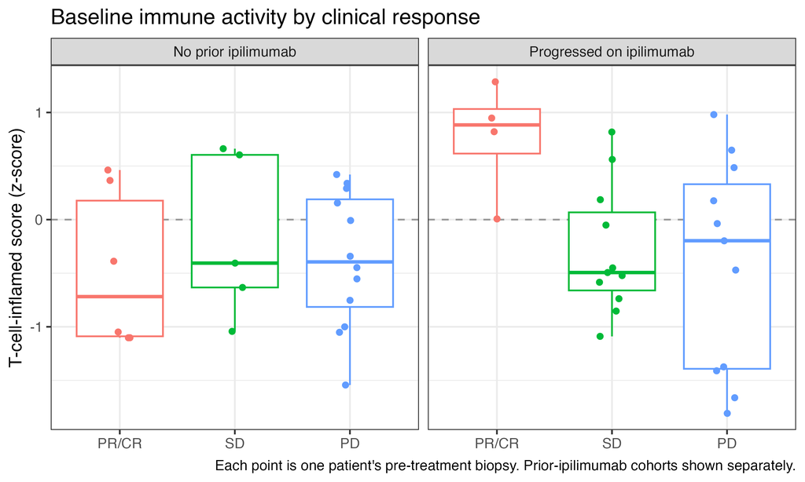

# Result 2: gene changes between biopsies

Responders change somewhat more genes, but the larger difference is consistency: DESeq2 finds many genes shifting together in PR/CR and almost none in SD or PD.

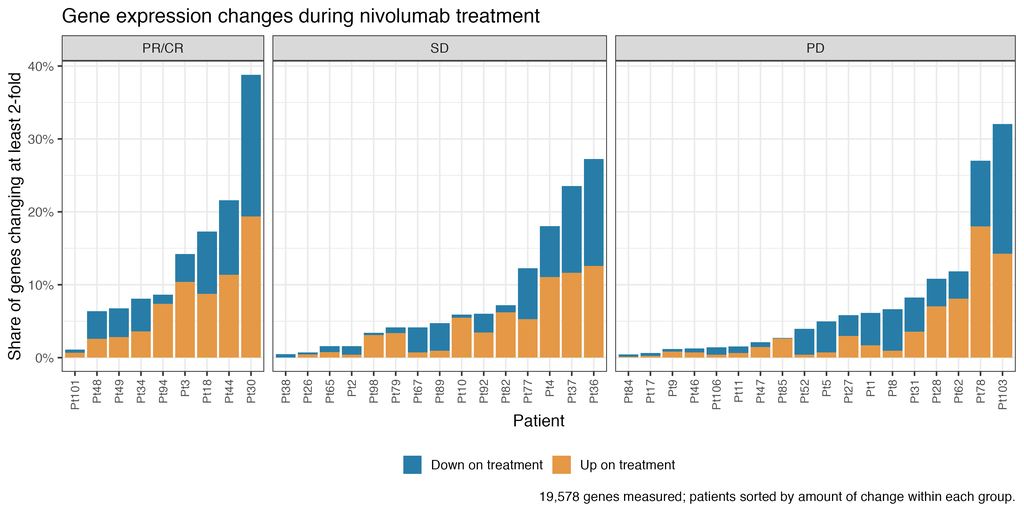

Significant genes per contrast

| contrast | genes_tested | fdr_0.1 | fdr_0.2 |
| --- | --- | --- | --- |
| A_pre_PRCR_vs_PD | 19196 | 223 | 460 |
| B_on_vs_pre_paired | 15023 | 44 | 227 |
| C_on_vs_pre_PRCR | 17680 | 3582 | 5629 |
| C_on_vs_pre_SD | 15782 | 28 | 88 |
| C_on_vs_pre_PD | 19578 | 0 | 0 |
| C_on_vs_pre_PRCR_vs_PD | 16921 | 1721 | 3479 |
| D_on_vs_pre_benefit_vs_none | 19578 | 6 | 7 |

# Result 3: tumor and immune change in each patient

The tumor score falls sharply in responders. The CD8 score rises in PR/CR and SD alike, so immune activation by itself is not specific to tumor shrinkage.

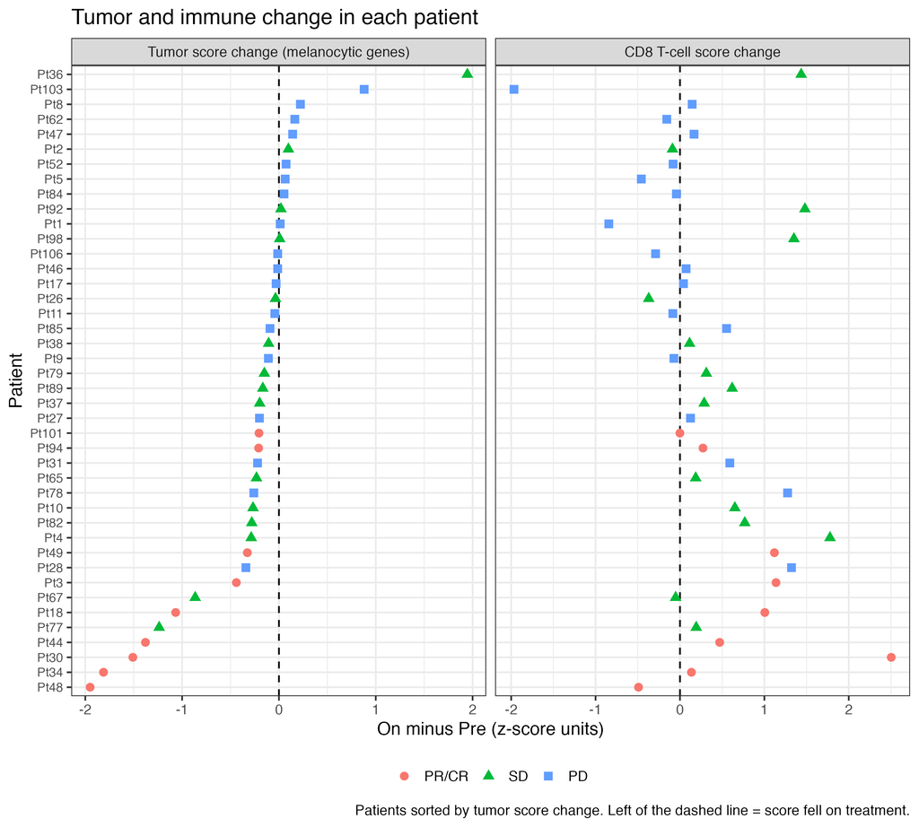

# Result 4: pathways

Immune pathways rise in all groups. Proliferation falls in responders and mostly rises in progressors.

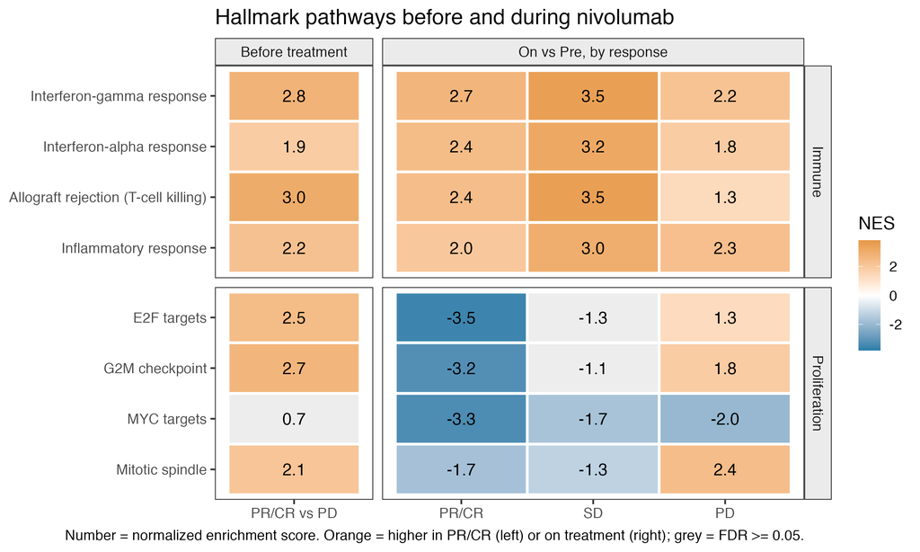

# Result 5: agreement with WES and TCR

The RNA tumor score tracks Kwaku’s mutation contraction, and the RNA CD8 score tracks the T-cell fraction from TCR-seq.

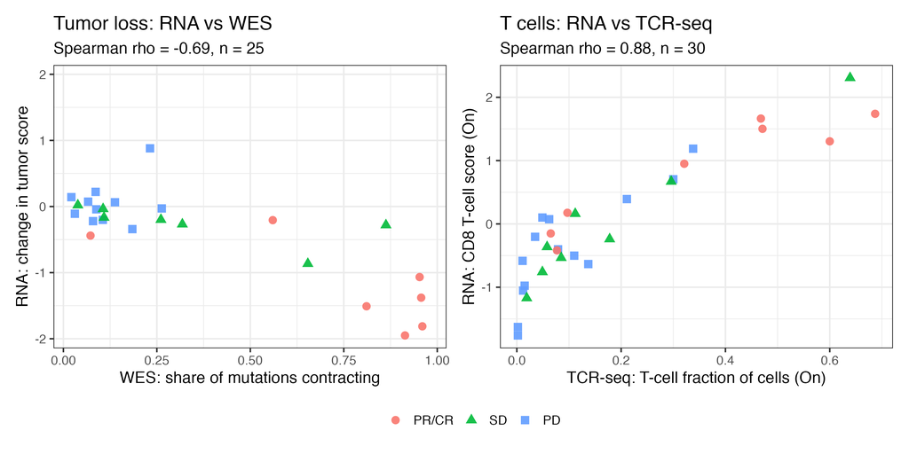

Spearman correlations

| comparison | rho | p | n |
| --- | --- | --- | --- |
| RNA CD8 vs TCR T-cell fraction, Pre | 0.807 | 0.000 | 29 |
| RNA CD8 vs TCR T-cell fraction, On | 0.876 | 0.000 | 30 |
| Change in cytotoxic score vs change in TCR clonality | 0.271 | 0.163 | 28 |
| Change in tumor score vs WES contraction | -0.695 | 0.000 | 25 |
| Change in tumor score vs WES contraction, excluding PR/CR | -0.501 | 0.034 | 18 |
| Change in CD8 score vs WES contraction | 0.062 | 0.767 | 25 |
| Change in tumor score vs neoantigen observed/expected | 0.280 | 0.175 | 25 |
| Baseline immune score vs mutation burden | 0.144 | 0.349 | 44 |

# Tables of effect sizes

Group medians with bootstrap 95% CIs

| measure | group | n | median | lo | hi |
| --- | --- | --- | --- | --- | --- |
| baseline_immune_score | PR/CR | 10 | 0.186 | -1.049 | 0.820 |
| baseline_immune_score | SD | 16 | -0.472 | -0.633 | 0.187 |
| baseline_immune_score | PD | 23 | -0.342 | -0.753 | 0.155 |
| baseline_immune_score | PR/CR minus PD | NA | 0.528 | -0.734 | 1.331 |
| baseline_cd8_score | PR/CR | 10 | 0.276 | -0.764 | 0.982 |
| baseline_cd8_score | SD | 16 | -0.302 | -0.958 | 0.191 |
| baseline_cd8_score | PD | 23 | -0.511 | -0.668 | 0.115 |
| baseline_cd8_score | PR/CR minus PD | NA | 0.787 | -0.560 | 1.445 |
| share_genes_changed | PR/CR | 9 | 0.086 | 0.064 | 0.216 |
| share_genes_changed | SD | 15 | 0.047 | 0.016 | 0.123 |
| share_genes_changed | PD | 18 | 0.045 | 0.015 | 0.074 |
| share_genes_changed | PR/CR minus PD | NA | 0.042 | 0.004 | 0.160 |
| tumor_score_change | PR/CR | 9 | -1.067 | -1.812 | -0.210 |
| tumor_score_change | SD | 15 | -0.166 | -0.268 | -0.036 |
| tumor_score_change | PD | 18 | -0.013 | -0.101 | 0.069 |
| tumor_score_change | PR/CR minus PD | NA | -1.054 | -1.770 | -0.229 |
| cd8_score_change | PR/CR | 9 | 0.470 | -0.001 | 1.138 |
| cd8_score_change | SD | 15 | 0.312 | 0.114 | 1.350 |
| cd8_score_change | PD | 18 | 0.000 | -0.120 | 0.155 |
| cd8_score_change | PR/CR minus PD | NA | 0.471 | 0.001 | 1.197 |
| immune_score_change | PR/CR | 9 | 0.438 | -0.167 | 1.084 |
| immune_score_change | SD | 15 | 0.443 | 0.137 | 0.940 |
| immune_score_change | PD | 18 | 0.053 | -0.018 | 0.238 |
| immune_score_change | PR/CR minus PD | NA | 0.385 | -0.197 | 0.970 |
| ifng_score_change | PR/CR | 9 | 0.129 | -0.693 | 1.097 |
| ifng_score_change | SD | 15 | 0.640 | 0.178 | 1.061 |
| ifng_score_change | PD | 18 | 0.165 | 0.087 | 0.303 |
| ifng_score_change | PR/CR minus PD | NA | -0.036 | -0.844 | 0.907 |
| cd8_score_on | PR/CR | 12 | 1.350 | 0.563 | 1.698 |
| cd8_score_on | SD | 18 | 0.198 | -0.301 | 0.779 |
| cd8_score_on | PD | 24 | -0.312 | -0.583 | 0.195 |
| cd8_score_on | PR/CR minus PD | NA | 1.662 | 0.748 | 2.154 |

Wilcoxon PR/CR vs PD: all patients, shared patients, and without Pt3

| measure | p_all | p_shared_patients | p_without_Pt3 |
| --- | --- | --- | --- |
| baseline_immune_score | 0.2030 | 0.3191 | 0.1021 |
| baseline_cd8_score | 0.1643 | 0.3191 | 0.0783 |
| share_genes_changed | 0.0477 | 0.1031 | 0.0801 |
| tumor_score_change | 0.0002 | 0.0011 | 0.0003 |
| cd8_score_change | 0.0679 | 0.2048 | 0.1133 |
| immune_score_change | 0.2076 | 0.5261 | 0.3309 |
| ifng_score_change | 0.9795 | 0.4687 | 0.6769 |
| cd8_score_on | 0.0004 | 0.0185 | 0.0002 |

PR/CR effect on CD8, before and after adjusting for tumor score

| model | PRCR_effect | lo | hi | p | n |
| --- | --- | --- | --- | --- | --- |
| CD8 change | 0.667 | 0.012 | 1.322 | 0.046 | 27 |
| CD8 change, adjusted for tumor score change | 0.209 | -0.743 | 1.161 | 0.655 | 27 |
| CD8 on treatment | 1.295 | 0.684 | 1.906 | 0.000 | 36 |
| CD8 on treatment, adjusted for tumor score on treatment | 1.207 | 0.521 | 1.894 | 0.001 | 36 |

Significant genes at FDR/q < 0.2: paper vs this R and DESeq2

| comparison | paper_q0.2 | authors_design_this_R | our_pipeline_fdr0.2 |
| --- | --- | --- | --- |
| Pre: PR/CR vs PD | 189 | 397 | 460 |
| On vs Pre, all patients | 475 | 157 | 227 |
| On vs Pre change: benefit vs no benefit | 2670 | NA | 7 |
| On vs Pre change: PR/CR vs PD | NA | NA | 3479 |

# Summary

- **Baseline immune activity is a weak predictor** at the level of patient scores, though immune pathways lean higher in responders.
- **Tumor loss is what marks a response.** Melanoma and proliferation programs fall in PR/CR, and the tumor score tracks WES contraction.
- **Immune activation is not enough.** Immune pathways rise in every group, including patients whose tumors do not shrink. The on-treatment CD8 level does separate PR/CR from PD, and it survives adjustment for tumor score.

# Limitations

- Bulk RNA is a mixture. Tumor loss raises the share of every other cell type, and the responder CD8 *rise* cannot be separated from this dilution. The on-treatment CD8 *level* holds up.
- Response is defined by tumor shrinkage, so the tumor score partly restates the outcome.
- The paper’s gene counts were not reproduced (see table). The authors used DESeq2 1.12.4 and, for Table S6A, IHW, and there is no public script for their Table S6D. The biological direction agrees.
- The paper removed Pt3 as an outlier, though the authors’ public scripts keep it. We keep it and report the tests without it.
- Enrichment p-values are optimistic because genes in a pathway are correlated. Read the direction and pattern.
- Groups are small and each biopsy is one snapshot. Figures use all 42 patients with paired RNA, not only the 26 shared across all three data types.